# Inferring a Common Rate

Lee & Wagenmakers Part II. 3.3, p43

cn

2023-04-04

```r
set.seed(12345)

if (!require("pacman", quietly = TRUE)) install.packages("pacman")
if (!require("rjags", quietly = TRUE)) install.packages("rjags")
pacman::p_load(cowplot, R2jags, psych)
pacman::p_load_gh("RLesur/klippy")

klippy::klippy()
```

# 1 Graphic model

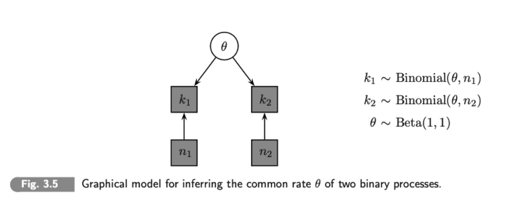

# 2 Running MCMC

## 2.1 Setups

자료와 변수, 초기값, 파라미터를 설정한다. 이진적 결과가 나오는 10회 시행을 두 차례 실시했을 때, 특정 값이 각각 5번과 7번 산출되었다. 이제 해당 반응의 비율 *theta* 파라미터를 한 개의 체인에서 표집해보자.

```r
# 자료
k1 <- 5
k2 <- 7
n1 <- 10
n2 <- 10

data <- list("k1", "k2", "n1", "n2") # to be passed on to JAGS
myinits <-  list(
  list(theta = 0.5))

# 관찰할 파라미터(parameters to be monitored):
parameters <- c("theta")
```

## 2.2 Model & MCMC

```r
model_text <- "
# Inferring a Common Rate
model{
   # Observed Counts
   k1 ~ dbin(theta,n1)
   k2 ~ dbin(theta,n2)
   # Prior on Single Rate Theta
   theta ~ dbeta(1,1)
}
"

samples <- jags(data, inits=myinits, parameters,
                 model.file = textConnection(model_text),
                 n.chains=1, n.iter=1000,
         n.burnin=1, n.thin=1, DIC=T)
```

```
## module glm loaded
```

이제 관찰한 파라미터의 값들이 **samples** 객체에 저장되었으니 자세히 살펴보자.

# 3 Visualization

## 3.1 Raw codes

먼저, `print()`로 요약된 결과를 보자. 1천 번 표집을 했고 처음 표본을 버렸으니 `n.sims = 999`가 되고, 그 분포가 요약되어 있다. 체인이 한 개였으므로 **R-hat** 즉, $\hat{x}$은 제시되지 않는다.

```r
print(samples)
```

```
## Inference for Bugs model at "4", fit using jags,
##  1 chains, each with 1000 iterations (first 1 discarded)
##  n.sims = 999 iterations saved
##          mu.vect sd.vect  2.5%   25%   50%   75%  97.5%
## theta      0.586   0.102 0.391 0.515 0.591 0.660  0.785
## deviance   7.212   1.291 6.287 6.376 6.739 7.514 10.554
##
## DIC info (using the rule, pD = var(deviance)/2)
## pD = 0.8 and DIC = 8.0
## DIC is an estimate of expected predictive error (lower deviance is better).
```

다루기 쉽도록, 파라미터의 사후분포 표본(posterior samples)를 *theta*라는 변수에 넣고 사후분포를 그려보자.

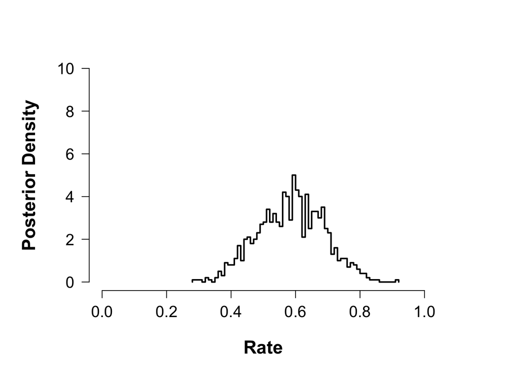

```r
theta <- samples$BUGSoutput$sims.list$theta

par(cex.main = 1.5, mar = c(5, 6, 4, 5) + 0.1, mgp = c(3.5, 1, 0), cex.lab = 1.5,
    font.lab = 2, cex.axis = 1.3, bty = "n", las=1)
Nbreaks <- 80
y       <- hist(theta, Nbreaks, plot=F)
plot(c(y$breaks, max(y$breaks)), c(0,y$density,0), type="S", lwd=2, lty=1,
     xlim=c(0,1), ylim=c(0,10), xlab="Rate", ylab="Posterior Density")
```

## 3.2 [CalvinBayes](https://rpruim.github.io/Kruschke-Notes/jags-just-another-gibbs-sampler.html)

가장 먼저 `as.mcmc()`를 통해 `samples`를 mcmc 객체로 변환한다. 이제 `plot()`으로 traceplot과 사후분포를 한꺼번에 확인할 수 있다.

```r
pacman::p_load_gh("rpruim/CalvinBayes")

# 1. 가장 먼저 coda::as.mcmc로 전체 그림을 그린다.
samples.mcmc <- as.mcmc(samples)
head(samples.mcmc)
```

```
## [[1]]
## Markov Chain Monte Carlo (MCMC) output:
## Start = 2
## End = 8
## Thinning interval = 1
##      deviance     theta
## [1,] 6.362551 0.5695907
## [2,] 6.340509 0.5744088
## [3,] 6.300508 0.5870488
## [4,] 7.183282 0.4944519
## [5,] 7.037223 0.6915652
## [6,] 7.632201 0.4706027
## [7,] 6.631349 0.6629029
##
## attr(,"class")
## [1] "mcmc.list"
```

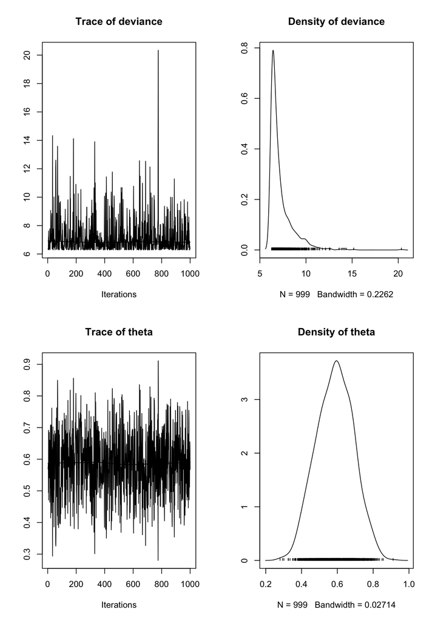

```r
plot(samples.mcmc)
```

`posterior()`는 posterior를 쓰면 samples을 쉽게 꺼낼 수 있다.

```r
p <- posterior(samples) # tidy df로 샘플을 추출한다.
psych::headTail(p)
```

```
##     deviance theta   chain iter
## 1       6.36  0.57 chain:1    1
## 2       6.34  0.57 chain:1    2
## 3        6.3  0.59 chain:1    3
## 4       7.18  0.49 chain:1    4
## ...      ...   ...    <NA>  ...
## 996     6.29   0.6 chain:1  996
## 997     6.55  0.66 chain:1  997
## 998     6.35  0.63 chain:1  998
## 999     6.37  0.57 chain:1  999
```

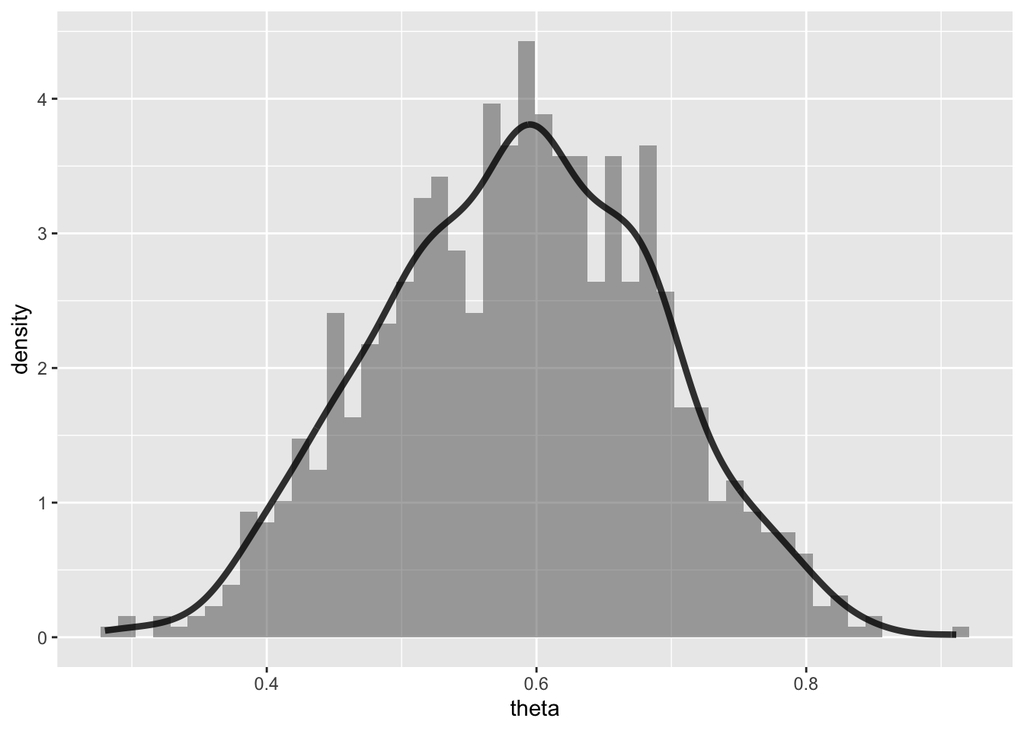

```r
# d <- as_tibble(samples$BUGSoutput$sims.matrix) # 이렇게도 할 수 있다.

p %>%
    gf_dhistogram(~theta, bins = 50) %>%
    gf_dens(~theta, size = 1.5, alpha = 0.8)
```

아래는 Kruschke 스타일의 플롯들이다. Mode와 HDI를 모두 보여준다.

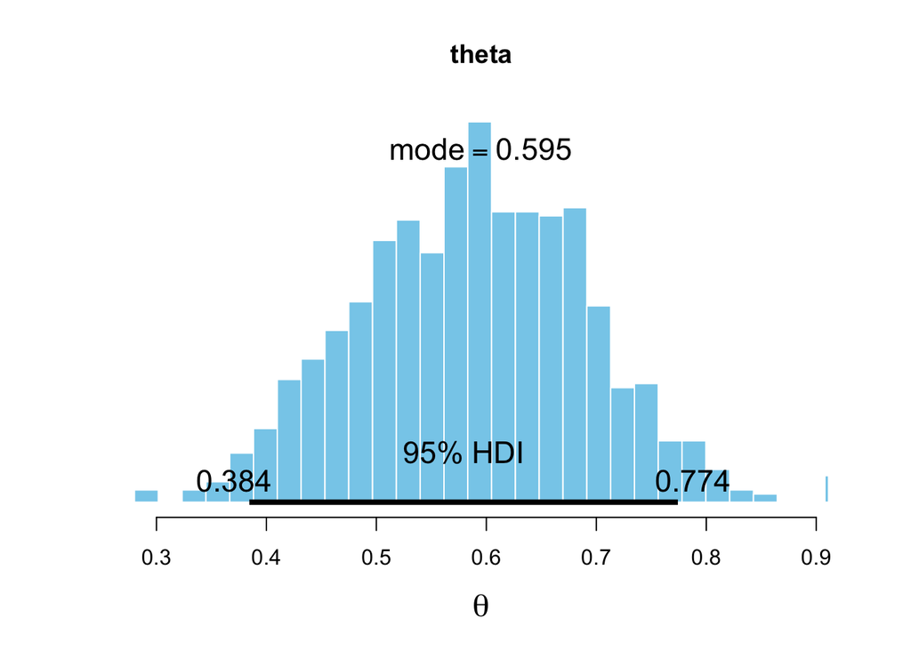

```
## $posterior
##           ESS      mean    median      mode
## var1 798.5648 0.5864603 0.5911849 0.5948711
##
## $hdi
##   prob        lo        hi
## 1 0.95 0.3844883 0.7741784
```

```r
plot_post(p$theta, main = "theta", xlab = expression(theta))
```

## 3.3 [GGDist](https://github.com/mjskay/ggdist/blob/master/figures-source/cheat_sheet-slabinterval.pdf)

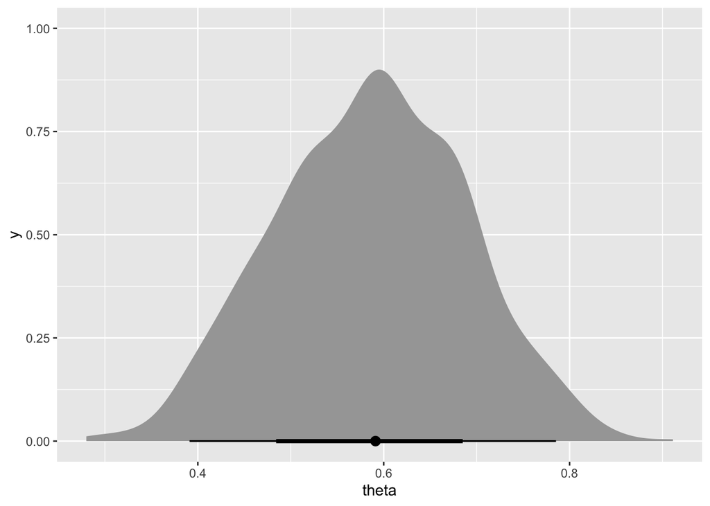

```r
pacman::p_load(tidyverse, ggdist)

p %>% ggplot(aes(x = theta)) +
    stat_halfeye()
```

앞에서 계산했던 대푯값을 보여주는 함수들이다.

```r
summary(p)
```

```
##     deviance          theta           chain                iter
##  Min.   : 6.287   Min.   :0.2800   Length:999         Min.   :  1.0
##  1st Qu.: 6.376   1st Qu.:0.5152   Class :character   1st Qu.:250.5
##  Median : 6.739   Median :0.5912   Mode  :character   Median :500.0
##  Mean   : 7.212   Mean   :0.5865                      Mean   :500.0
##  3rd Qu.: 7.514   3rd Qu.:0.6602                      3rd Qu.:749.5
##  Max.   :20.342   Max.   :0.9112                      Max.   :999.0
```

```r
mode_hdi(p$theta)
```

```
##           y      ymin      ymax .width .point .interval
## 1 0.5950064 0.3858886 0.7741784   0.95   mode       hdi
```

```r
median_qi(p$theta)
```

```
##           y      ymin      ymax .width .point .interval
## 1 0.5911849 0.3910923 0.7853789   0.95 median        qi
```

```r
mean_qi(p$theta)
```

```
##           y      ymin      ymax .width .point .interval
## 1 0.5864603 0.3910923 0.7853789   0.95   mean        qi
```

## 3.4 [cowplot](https://bookdown.org/content/3686/markov-chain-monte-carlo.html)

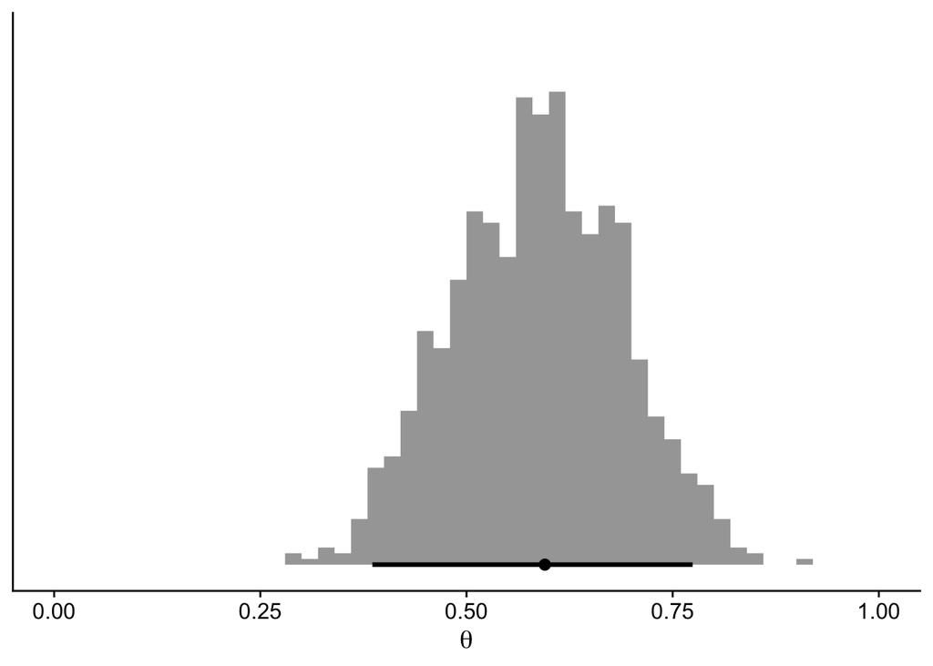

```r
pacman::p_load(cowplot)

p %>%
    ggplot(aes(x = theta, y = 0)) +
    stat_histinterval(point_interval = mode_hdi, .width = .95, breaks = 30) +
    scale_x_continuous(expression(theta), limits = c(0, 1)) +
    scale_y_continuous(NULL, breaks = NULL) +
    theme_cowplot()
```

## 3.5 [bayesplot](https://mc-stan.org/bayesplot/reference/MCMC-intervals.html)

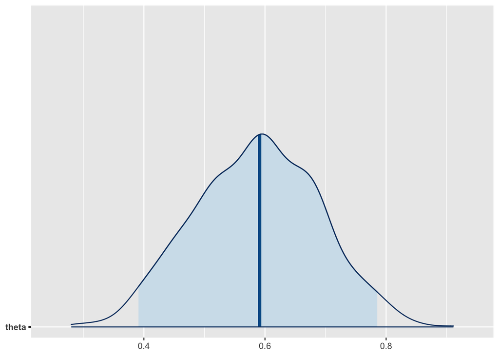

```r
library(bayesplot)
mcmc_areas(
    samples,
    pars = c("theta"),     # make a plot for the theta parameter
    prob = 0.95)           # shade the central 90%
```

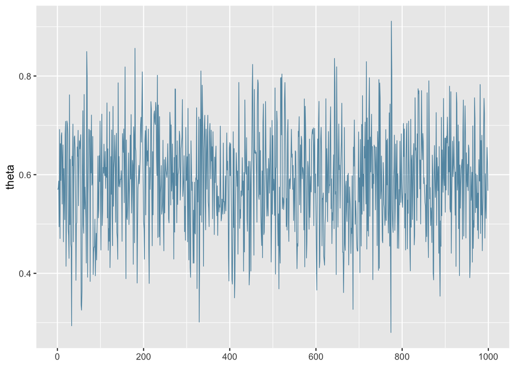

```r
mcmc_trace(samples.mcmc, pars = "theta")
```

# 4 Session Info

```r
sessionInfo()
## R version 4.2.3 (2023-03-15)
## Platform: aarch64-apple-darwin20 (64-bit)
## Running under: macOS Ventura 13.3
##
## Matrix products: default
## BLAS:   /Library/Frameworks/R.framework/Versions/4.2-arm64/Resources/lib/libRblas.0.dylib
## LAPACK: /Library/Frameworks/R.framework/Versions/4.2-arm64/Resources/lib/libRlapack.dylib
##
## locale:
## [1] en_US.UTF-8/en_US.UTF-8/en_US.UTF-8/C/en_US.UTF-8/en_US.UTF-8
##
## attached base packages:
## [1] stats     graphics  grDevices utils     datasets  methods   base
##
## other attached packages:
##  [1] ggdist_3.2.1      lubridate_1.9.2   forcats_1.0.0     stringr_1.5.0
##  [5] purrr_1.0.1       readr_2.1.4       tidyr_1.3.0       tibble_3.2.1
##  [9] tidyverse_2.0.0   CalvinBayes_0.2.6 bayesplot_1.10.0  ggformula_0.10.2
## [13] ggridges_0.5.4    scales_1.2.1      ggstance_0.3.6    ggplot2_3.4.2
## [17] dplyr_1.1.1       klippy_0.0.0.9500 psych_2.3.3       R2jags_0.7-1
## [21] cowplot_1.1.1     rjags_4-13        coda_0.19-4       pacman_0.5.1
##
## loaded via a namespace (and not attached):
##   [1] backports_1.4.1      plyr_1.8.8           igraph_1.4.1
##   [4] crosstalk_1.2.0      rstantools_2.3.1     inline_0.3.19
##   [7] digest_0.6.31        htmltools_0.5.5      magick_2.7.4
##  [10] fansi_1.0.4          magrittr_2.0.3       checkmate_2.1.0
##  [13] tzdb_0.3.0           mosaicCore_0.9.2.1   brms_2.19.0
##  [16] RcppParallel_5.1.7   matrixStats_0.63.0   xts_0.13.0
##  [19] timechange_0.2.0     prettyunits_1.1.1    colorspace_2.1-0
##  [22] haven_2.5.2          xfun_0.38            callr_3.7.3
##  [25] crayon_1.5.2         jsonlite_1.8.4       zoo_1.8-11
##  [28] glue_1.6.2           polyclip_1.10-4      gtable_0.3.3
##  [31] distributional_0.3.2 pkgbuild_1.4.0       rstan_2.21.8
##  [34] abind_1.4-5          mvtnorm_1.1-3        DBI_1.1.3
##  [37] miniUI_0.1.1.1       Rcpp_1.0.10          xtable_1.8-4
##  [40] HDInterval_0.2.4     stats4_4.2.3         StanHeaders_2.21.0-7
##  [43] DT_0.27              htmlwidgets_1.6.2    threejs_0.3.3
##  [46] posterior_1.4.1      ellipsis_0.3.2       pkgconfig_2.0.3
##  [49] loo_2.6.0            farver_2.1.1         sass_0.4.5
##  [52] utf8_1.2.3           tidyselect_1.2.0     labeling_0.4.2
##  [55] rlang_1.1.0          reshape2_1.4.4       later_1.3.0
##  [58] munsell_0.5.0        tools_4.2.3          cachem_1.0.7
##  [61] cli_3.6.1            generics_0.1.3       broom_1.0.4
##  [64] evaluate_0.20        fastmap_1.1.1        yaml_2.3.7
##  [67] processx_3.8.0       knitr_1.42           tidygraph_1.2.3
##  [70] nlme_3.1-162         mime_0.12            compiler_4.2.3
##  [73] shinythemes_1.2.0    rstudioapi_0.14      tweenr_2.0.2
##  [76] bslib_0.4.2          stringi_1.7.12       highr_0.10
##  [79] ps_1.7.4             Brobdingnag_1.2-9    lattice_0.20-45
##  [82] Matrix_1.5-3         markdown_1.5         shinyjs_2.1.0
##  [85] tensorA_0.36.2       vctrs_0.6.1          pillar_1.9.0
##  [88] lifecycle_1.0.3      jquerylib_0.1.4      bridgesampling_1.1-2
##  [91] httpuv_1.6.9         R2WinBUGS_2.1-21     R6_2.5.1
##  [94] promises_1.2.0.1     gridExtra_2.3        codetools_0.2-19
##  [97] boot_1.3-28.1        colourpicker_1.2.0   MASS_7.3-58.3
## [100] gtools_3.9.4         assertthat_0.2.1     withr_2.5.0
## [103] ggdag_0.2.8          shinystan_2.6.0      mnormt_2.1.1
## [106] parallel_4.2.3       hms_1.1.3            grid_4.2.3
## [109] labelled_2.10.0      rmarkdown_2.21       ggforce_0.4.1
## [112] shiny_1.7.4          base64enc_0.1-3      dygraphs_1.1.1.6
```